#### 22.1.25

# Week 2 Missing Data & Smoothing Models

```python
import sklearn
import seaborn as sns
import numpy as np
import pandas as pd
import matplotlib.pyplot as plt
```

```python
data=pd.read_csv('/Users/Devyani/msads/timeseries/hw2/hw2_data.csv')
```

### 1: 20 pts - Exploratory Data Analysis

```python
def perform_eda(data):
    print("Missing Data:\n", data.isnull().sum())
    print("\nSummary Statistics:\n", data.describe())
    print("\nCorrelation Matrix:\n", data[['IWM', 'QQQ', 'SPY']].corr())
    print("\nColumn Names:\n",data.columns.tolist())
```

```python
perform_eda(data)
```

```
Missing Data:
 Date      0
IWM     897
QQQ     897
SPY     897
dtype: int64

Summary Statistics:
                IWM          QQQ          SPY
count  4075.000000  4075.000000  4075.000000
mean     76.803903    69.936104   133.560141
std      38.574049    48.771959    66.423841
min      25.456144    17.459492    53.503864
25%      45.671591    34.224882    85.664322
50%      63.684242    48.152367   105.580437
75%     105.815506    97.974091   178.118759
max     167.320114   235.638428   332.137360

Correlation Matrix:
           IWM       QQQ       SPY
IWM  1.000000  0.950661  0.982749
QQQ  0.950661  1.000000  0.986471
SPY  0.982749  0.986471  1.000000

Column Names:
 ['Date', 'IWM', 'QQQ', 'SPY']
```

#### 1: 5 pts Plot the data

[figure not shown]

```python
plt.figure(figsize=(12, 6))
for column in data.columns:
    plt.plot(data.index, data[column], label=column, alpha=0.7)
plt.title("Time Series Data: IWM, QQQ, SPY")
plt.xlabel("Date")
plt.ylabel("Value")
plt.legend()
plt.grid()
plt.show()
```

#### 2: 5 pts From looking at the plot, does there appear to be missing data?

Yes, there appears to be missing data. We can see that every time series has some NA values, and can look closer to see how many there are.

#### 3: 5 pts How many NA values appear in each time series? What percentage of data is missing? Give one reason why we might be missing data in this pattern?

```python
missing_data_stats = data.isna().sum()
missing_percentage = (missing_data_stats / len(data)) * 100
```

```python
print("Missing Data Summary:")
print(missing_data_stats)
print("Missing Percentage (%):")
print(missing_percentage)
```

```
Missing Data Summary:
Date      0
IWM     897
QQQ     897
SPY     897
dtype: int64
Missing Percentage (%):
Date     0.00000
IWM     18.04103
QQQ     18.04103
SPY     18.04103
dtype: float64
```

In the above printed statistics we can see the number of missing datapoints for each time series, as well as the percentages of missing data. We may be missing data in this pattern across all time series because of market holidays or market data outages.

#### 4: 5 pts Describe one business case where you would notproceed with this much missing data. Describe one business case where you would proceed with this much missing data.

We would **not** proceed with this much missing data in a high-frequency trading capacity, where we would need very precise and accurate estimates to be done down to the microsecond, and interpolation and filling would not provide sufficient reliability. We **would** proceed with this much missing data in the event that we are investigating long-term trends or sorting out retirement portfolios, where minute accuracy is less important than overall and holistic analysis.

### 2: 20 pts - Missing Data

#### 1: 5 pts Create a forward fill

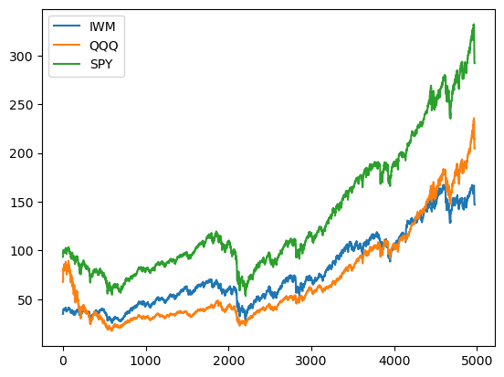

```python
data_ff =data.fillna(method='ffill')
data_ff.plot()
plt.show()
data.plot(color='red')
plt.show()
```

```python
print("Forward Fill:")
print(data_ff.head())
```

```
Forward Fill:
         Date        IWM        QQQ         SPY
0  2000-05-26  34.800865  67.670738   93.363678
1  2000-05-30  34.800865  67.670738   93.363678
2  2000-05-31  34.800865  67.670738   93.363678
3  2000-06-01  37.036850  76.048004   98.310966
4  2000-06-02  38.963646  81.487755  100.023491
```

#### 2: 5 pts Create a backward fill

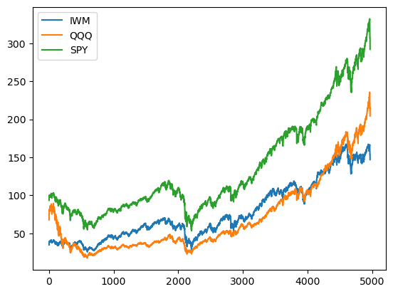

```python
data_bf = data.fillna(method='bfill')
data_bf.plot()
plt.show()
data.plot(color='red')
plt.show()
```

```python
print("\nBackward Fill:")
print(data_bf.head())
```

```
Backward Fill:
         Date        IWM        QQQ         SPY
0  2000-05-26  34.800865  67.670738   93.363678
1  2000-05-30  37.036850  76.048004   98.310966
2  2000-05-31  37.036850  76.048004   98.310966
3  2000-06-01  37.036850  76.048004   98.310966
4  2000-06-02  38.963646  81.487755  100.023491
```

#### 3: 5 pts Create a moving average fill

```python
numeric_data = data.select_dtypes(include='number')
```

```python
def apply_mean_imputer(x, period):
    if not isinstance(x, pd.Series):
        x = pd.Series(x)
    results = []
    for i in range(1, len(x) + 1):
        slice_of_x = x.iloc[max(0, i - period):i]
        mean_of_x = slice_of_x.mean()
        results.append(mean_of_x)
    missing_results = pd.Series(results, index=x.index)
    missing_results = np.where(x.isnull(), missing_results, x)
    return pd.Series(missing_results, index=x.index)
```

```python
period = 5
data_mean_imputed = numeric_data.apply(lambda col: apply_mean_imputer(col, period))
```

```python
final_data = pd.concat([data_mean_imputed, data.drop(columns=numeric_data.columns)], axis=1)
```

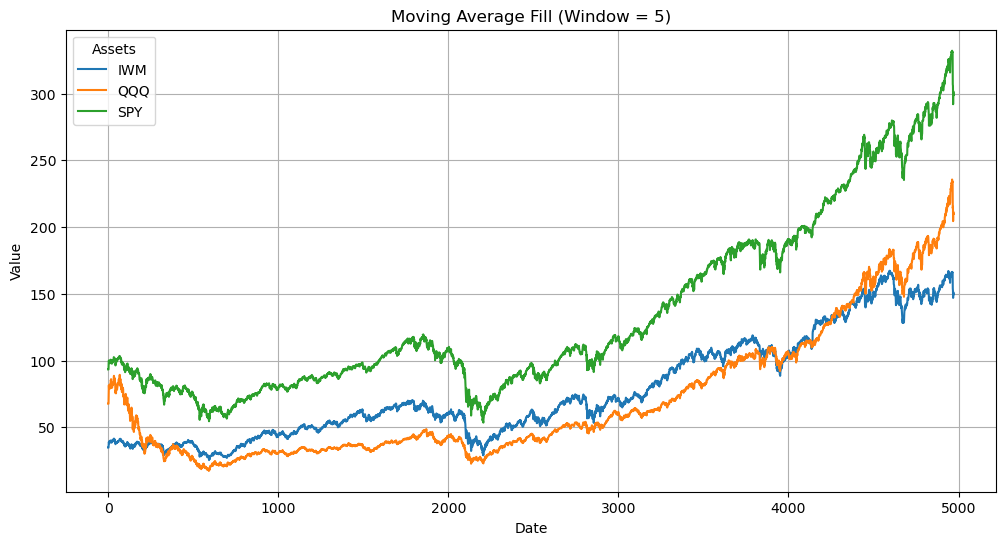

```python
data_mean_imputed.plot(figsize=(12, 6), title="Moving Average Fill (Window = 5)")
plt.xlabel("Date")
plt.ylabel("Value")
plt.legend(title="Assets")
plt.grid()
plt.show()
```

#### 4: 5 pts Create an interpolation

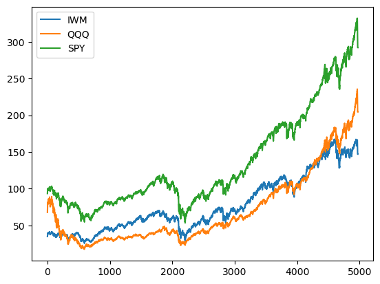

```python
data_int = data.interpolate()
data_int.plot()
plt.show()
data.plot(color='red')
plt.show()
```

### 60 pts -Smoothing Methods

```python
from statsmodels.tsa.holtwinters import SimpleExpSmoothing, ExponentialSmoothing
```

```python
def smape(y_true, y_pred):
    return 100 * np.mean(2 * np.abs(y_pred - y_true) / (np.abs(y_true) + np.abs(y_pred)))
data_ff = data.fillna(method='ffill')
target_series_ff = data_ff['SPY']
```

```python
train_size = int(len(target_series_ff) * 0.8)
train_ff = target_series_ff[:train_size]
test_ff = target_series_ff[train_size:]
```

```python
results = {}
```

```python
models = [
    {"name": "Simple Exponential Smoothing", "model": SimpleExpSmoothing, "params": {}},
    {"name": "Holt Additive Trend", "model": ExponentialSmoothing, "params": {"trend": "add", "seasonal": None}},
    {"name": "Holt Multiplicative Trend", "model": ExponentialSmoothing, "params": {"trend": "mul", "seasonal": None}},
    {"name": "Holt-Winters Additive", "model": ExponentialSmoothing, "params": {"trend": "add", "seasonal": "add", "seasonal_periods": 12}},
    {"name": "Holt-Winters Multiplicative", "model": ExponentialSmoothing, "params": {"trend": "mul", "seasonal": "mul", "seasonal_periods": 12}}
]
```

#### Please see results from 1-5 below:

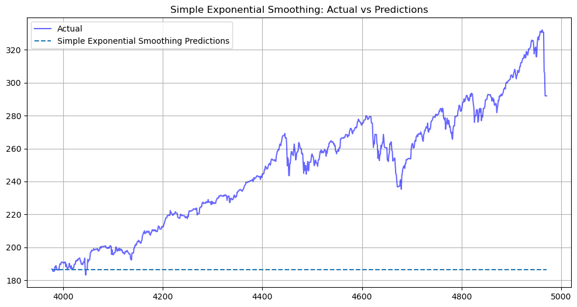

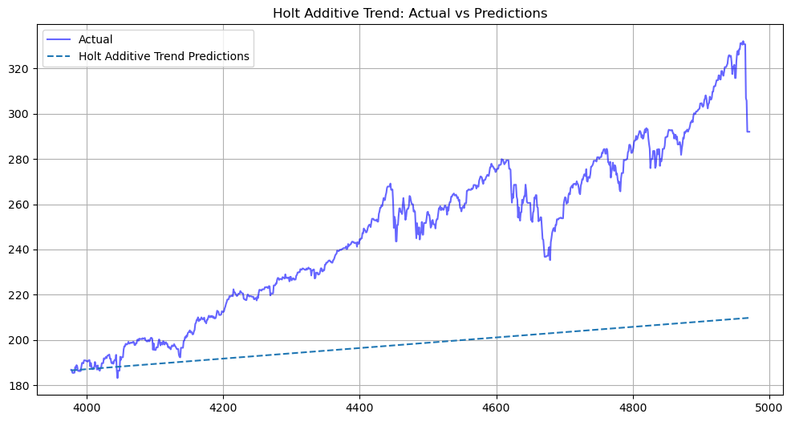

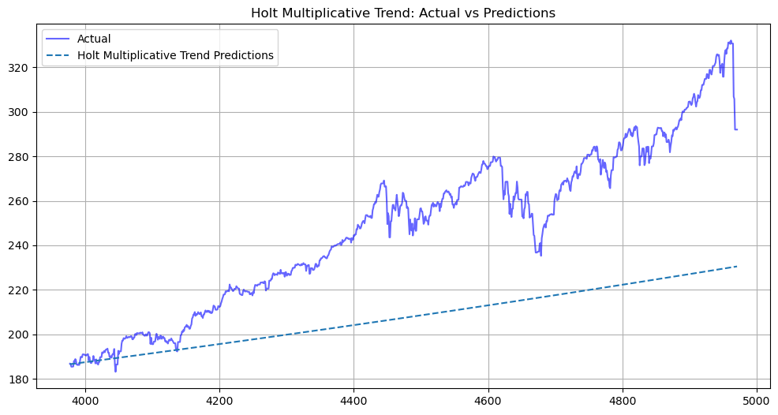

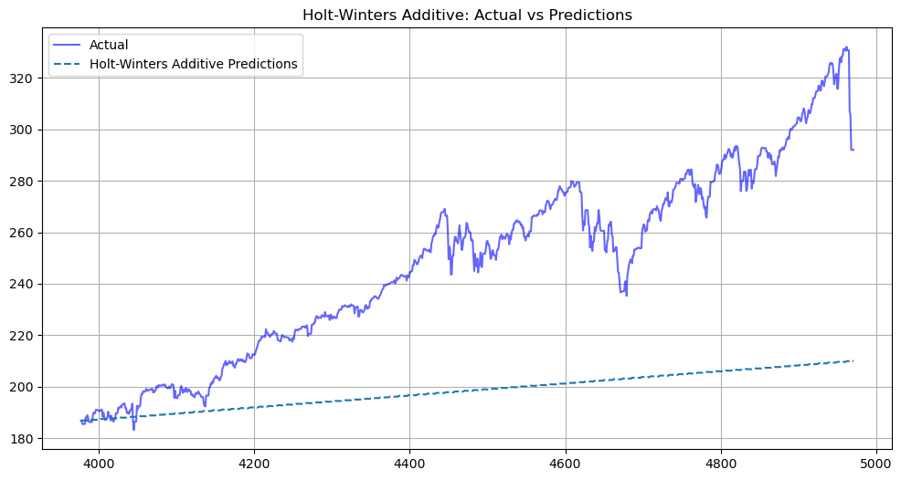

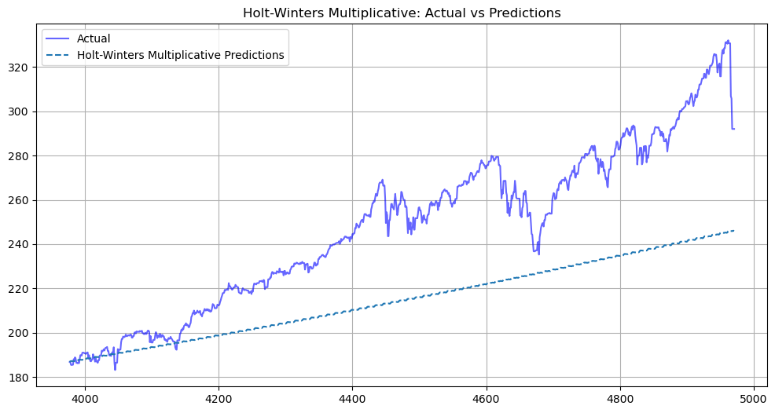

```python
for model_info in models:
    model_name = model_info["name"]
    model_class = model_info["model"]
    model_params = model_info["params"]
    model = model_class(train_ff, **model_params).fit(optimized=True)
    predictions = model.forecast(len(test_ff))
    model_smape = smape(test_ff, predictions)
    results[model_name] = {"model": model, "sMAPE": model_smape, "predictions": predictions}
    #plots
    plt.figure(figsize=(12, 6))
    plt.plot(test_ff, label="Actual", color="blue", alpha=0.6)
    plt.plot(predictions, label=f"{model_name} Predictions", linestyle="--")
    plt.title(f"{model_name}: Actual vs Predictions")
    plt.legend()
    plt.grid()
    plt.show()
```

```python
print("sMAPE Results:")
for model_name, result in results.items():
    print(f"{model_name}: {result['sMAPE']:.2f}")
```

```
sMAPE Results:
Simple Exponential Smoothing: 27.03
Holt Additive Trend: 21.21
Holt Multiplicative Trend: 16.69
Holt-Winters Additive: 21.12
Holt-Winters Multiplicative: 13.39
```

#### 6 10pts Which is the best model, why is it working better? In general, does it make sense to model stock price data using this method?

Based on the SMAPE results, we can say that **Holt-Winters multiplicative trend and multiplicative seasonality** is the best model as it has the lowest SMAPE value. This model could be used for modelling stock price data if we can expect to see trends in the data, and Holt-Winters multiplicative accounts for a linear/proportional trend over time, and it also models seasonal variation in the data. However, given the unpredictable and volatile nature of stock markets and the lack of stationarity in the data, as stock prices can lack clear trends or seasonality due to market conditions, perhaps other models such as ARIMA would be best for modelling stock price data instead of Holt-Winters multiplicative. So -- in general, it does **not** make sense to model stock price data using this model.